# Text Analysis of Science books

Jajwalya R. Karajgikar

##Tidy Data Tidy text format is a table with one-token-per row. Some of the packages used are dplyr (Wickham and Francois 2016), tidyr (Wickham 2016), ggplot2 (Wickham 2009). tm (Feinerer, Hornik, and Meyer 2008) and quanteda (Benoit and Nulty 2016) can also be used.

#************************************************************************** # Analyzing a corpus of Science books #************************************************************************** #set working directory #setwd(“replace directory here”) #install and load the dplyr, tidytext, ggplot2, and gutenbergr library for text processing

```r
#install.packages("dplyr")
#install.packages("tidytext")
#install.packages("ggplot2")
#install.packages("gutenbergr")
```

#************************************************************************** ## Creating a corpus #************************************************************************** The gutenbergr package (Robinson 2016) provides access to the public domain works from the [Project Gutenberg](https://www.gutenberg.org/) collection including metadata. The function gutenberg_download() downloads one or more works from Project Gutenberg by ID. The texts Discourse on Floating Bodies by Galileo Galilei Treatise on Light by Christiaan Huygens Experiments with Alternate Currents of High Potential and High Frequency by Nikola Tesla Relativity: The Special and General Theory by Albert Einstein used are physics classics written across a 300-year timespan, and some of them were first written in other languages and then translated to English.

```r
library(dplyr)
```

```r
library(tidytext)
library(ggplot2)
library(gutenbergr)
physics <- gutenberg_download(c(37729, 14725, 13476, 30155),
                              meta_fields = "author")
```

```
## Determining mirror for Project Gutenberg from http://www.gutenberg.org/robot/harvest
```

```
## Using mirror http://aleph.gutenberg.org
```

#************************************************************************** ## Pre-processing the corpus #************************************************************************** ###How many times was each word used in each text? Unnest_tokens breaks the text into individual tokens and performs tokenization. dplyr’s count() finds the most common words in all the books as a whole.

```r
physics_words <- physics %>%
  unnest_tokens(word, text) %>%
  count(author, word, sort = TRUE)

physics_words
```

```
## # A tibble: 12,671 x 3
##    author              word      n
##    <chr>               <chr> <int>
##  1 Galilei, Galileo    the    3760
##  2 Tesla, Nikola       the    3604
##  3 Huygens, Christiaan the    3553
##  4 Einstein, Albert    the    2993
##  5 Galilei, Galileo    of     2049
##  6 Einstein, Albert    of     2028
##  7 Tesla, Nikola       of     1737
##  8 Huygens, Christiaan of     1708
##  9 Huygens, Christiaan to     1207
## 10 Tesla, Nikola       a      1176
## # … with 12,661 more rows
```

These are the raw counts. The documents are all different lengths. The term-frequency(tf) quantifies the frequently occurring terms. The inverse term-frequency(idf) decreases the weight for commonly used words and increases the weight for words that are not used very much in a collection of documents. The tf-idf together is a statistic to measure the frequency of a term adjusted for how rarely it is used. It measures how important a word is in the text.

```r
library(forcats)

plot_physics <- physics_words %>%
  bind_tf_idf(word, author, n) %>%
  mutate(word = fct_reorder(word, tf_idf)) %>%
  mutate(author = factor(author, levels = c("Galilei, Galileo",
                                            "Huygens, Christiaan",
                                            "Tesla, Nikola",
                                            "Einstein, Albert")))
```

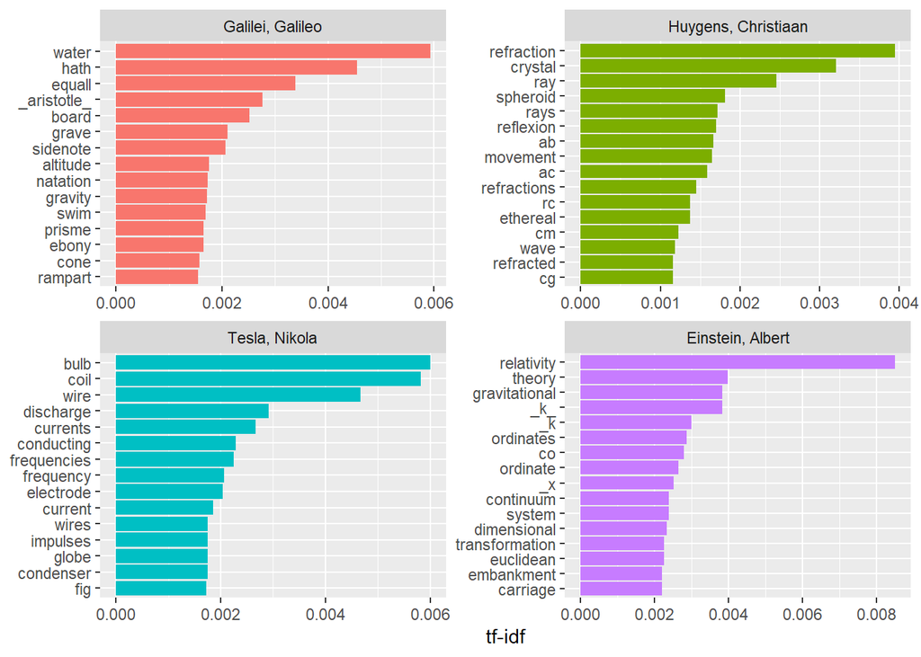

```r
plot_physics %>%
  group_by(author) %>%
  top_n(15, tf_idf) %>%
  ungroup() %>%
  mutate(word = reorder(word, tf_idf)) %>%
  ggplot(aes(word, tf_idf, fill = author)) +
  geom_col(show.legend = FALSE) +
  labs(x = NULL, y = "tf-idf") +
  facet_wrap(~author, ncol = 2, scales = "free") +
  coord_flip()
```

#************************************************************************** ## Removing specific stopwords from the corpus #************************************************************************** The filter() function narrows down the selected text. A custom list of stop words can be included with an anti_join() to remove them.

```r
library(stringr)
data(stop_words)

physics %>%
  filter(str_detect(text, "_k_")) %>%
  select(text)
```

```
## # A tibble: 7 x 1
##   text
##   <chr>
## 1 surface AB at the points AK_k_B. Then instead of the hemispherical
## 2 would needs be that from all the other points K_k_B there should
## 3 necessarily be equal to CD, because C_k_ is equal to CK, and C_g_ to
## 4 the crystal at K_k_, all the points of the wave CO_oc_ will have
## 5 O_o_ has reached K_k_. Which is easy to comprehend, since, of these
## 6 CO_oc_ in the crystal, when O_o_ has arrived at K_k_, because it forms
## 7 ρ is the average density of the matter and _k_ is a constant connected
```

```r
physics %>%
  filter(str_detect(text, "RC")) %>%
  select(text)
```

```
## # A tibble: 44 x 1
##    text
##    <chr>
##  1 line RC, parallel and equal to AB, to be a portion of a wave of light,
##  2 represents the partial wave coming from the point A, after the wave RC
##  3 be the propagation of the wave RC which fell on AB, and would be the
##  4 transparent body; seeing that the wave RC, having come to the aperture
##  5 incident rays. Let there be such a ray RC falling upon the surface
##  6 CK. Make CO perpendicular to RC, and across the angle KCO adjust OK,
##  7 the required refraction of the ray RC. The demonstration of this is,
##  8 explaining ordinary refraction. For the refraction of the ray RC is
##  9 29. Now as we have found CI the refraction of the ray RC, similarly
## 10 the ray _r_C is inclined equally with RC, the line C_d_ will
## # … with 34 more rows
```

```r
mystopwords <- tibble(word = c("eq", "co", "rc", "ac", "ak", "bn",
                               "fig", "file", "cg", "cb", "cm",
                               "ab", "_k", "_k_", "_x"))

physics_words <- anti_join(physics_words, mystopwords,
                           by = "word") %>%
  anti_join(stop_words)
head(physics_words)
```

```
## # A tibble: 6 x 3
##   author              word           n
##   <chr>               <chr>      <int>
## 1 Galilei, Galileo    water        828
## 2 Galilei, Galileo    gravity      240
## 3 Huygens, Christiaan refraction   218
## 4 Galilei, Galileo    air          211
## 5 Galilei, Galileo    mass         208
## 6 Huygens, Christiaan light        201
```

#************************************************************************** ## Word cloud text frequency from the corpus #************************************************************************** The more number of times a specific word appears in a source of textual data, the bigger and bolder it appears in the word cloud.

```r
library("SnowballC")
library("wordcloud")
library("RColorBrewer")

physics_words %>%
  count(word)
```

```
## # A tibble: 7,490 x 2
##    word           n
##    <chr>      <int>
##  1 _1             1
##  2 _2             1
##  3 _3             1
##  4 _a             3
##  5 _a_            3
##  6 _a_bsolute     1
##  7 _a_ir          1
##  8 _a_n           1
##  9 _a_ncients     1
## 10 _ab_           2
## # … with 7,480 more rows
```

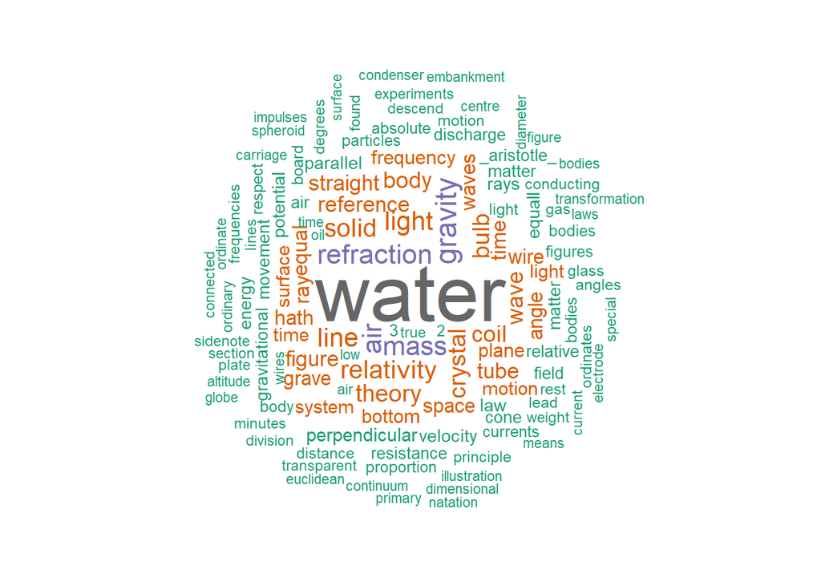

```r
wordcloud(physics_words$word, physics_words$n, min.freq = 50, max.words = 200, random.order=FALSE, rot.per=0.35, colors=brewer.pal(8, "Dark2"))
```

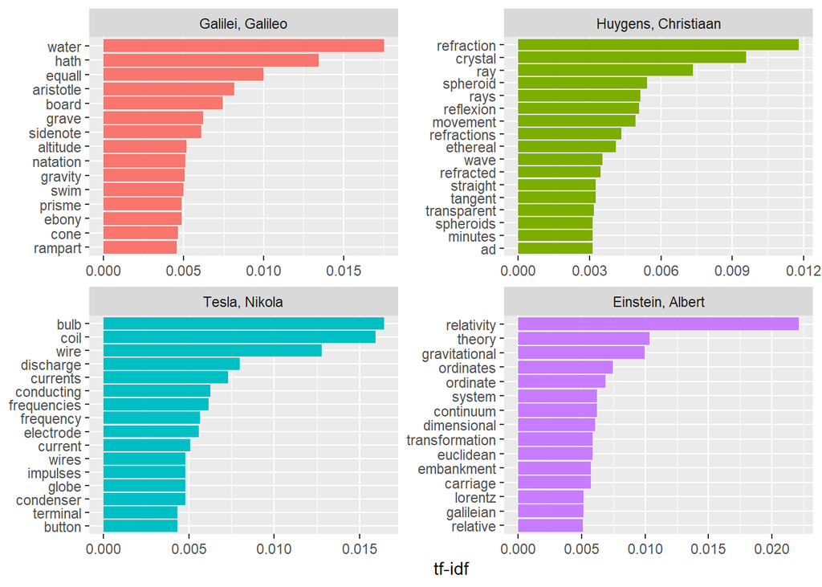

```r
plot_physics <- physics_words %>%
  bind_tf_idf(word, author, n) %>%
  mutate(word = str_remove_all(word, "_")) %>%
  group_by(author) %>%
  top_n(15, tf_idf) %>%
  ungroup() %>%
  mutate(word = reorder_within(word, tf_idf, author)) %>%
  mutate(author = factor(author, levels = c("Galilei, Galileo",
                                            "Huygens, Christiaan",
                                            "Tesla, Nikola",
                                            "Einstein, Albert")))

ggplot(plot_physics, aes(word, tf_idf, fill = author)) +
  geom_col(show.legend = FALSE) +
  labs(x = NULL, y = "tf-idf") +
  facet_wrap(~author, ncol = 2, scales = "free") +
  coord_flip() +
  scale_x_reordered()
```

#************************************************************************** ## N-grams analysis from the corpus #**************************************************************************

N-grams help to understand the relationships between words. Bigrams require unnesting tokens by groups of two words occurring together the most.

```r
physics_bigrams <- physics %>%
  unnest_tokens(bigram, text, token = "ngrams", n = 2)

physics_bigrams
```

```
## # A tibble: 149,423 x 3
##    gutenberg_id author        bigram
##           <int> <chr>         <chr>
##  1        13476 Tesla, Nikola experiments with
##  2        13476 Tesla, Nikola with alternate
##  3        13476 Tesla, Nikola alternate currents
##  4        13476 Tesla, Nikola currents of
##  5        13476 Tesla, Nikola of high
##  6        13476 Tesla, Nikola high potential
##  7        13476 Tesla, Nikola potential and
##  8        13476 Tesla, Nikola and high
##  9        13476 Tesla, Nikola high frequency
## 10        13476 Tesla, Nikola frequency a
## # … with 149,413 more rows
```

The most common bigrams from dplyr’s count().

```r
physics_bigrams%>%
  count(bigram, sort = TRUE)
```

```
## # A tibble: 59,858 x 2
##    bigram        n
##    <chr>     <int>
##  1 of the     2786
##  2 to the     1175
##  3 in the      980
##  4 that the    553
##  5 the water   505
##  6 it is       502
##  7 the same    471
##  8 and the     389
##  9 from the    349
## 10 to be       335
## # … with 59,848 more rows
```

Removing the stop words requires tidyr’s separate() splits a column into multiple based on a delimiter into two columns, “word1” and “word2”, removing cases where either is a stop-word.

```r
library(tidyr)

bigrams_separated <- physics_bigrams %>%
  separate(bigram, c("word1", "word2"), sep = " ")

bigrams_filtered <- bigrams_separated %>%
  filter(!word1 %in% stop_words$word) %>%
  filter(!word2 %in% stop_words$word)

# new bigram counts:
bigram_counts <- bigrams_filtered %>%
  count(word1, word2, sort = TRUE)

bigram_counts
```

```
## # A tibble: 9,783 x 3
##    word1         word2       n
##    <chr>         <chr>   <int>
##  1 straight      line      115
##  2 gravitational field      61
##  3 reference     body       56
##  4 straight      lines      49
##  5 absolute      gravity    43
##  6 ordinate      system     39
##  7 special       theory     37
##  8 cone          _a         35
##  9 illustration  fig        33
## 10 ethereal      matter     31
## # … with 9,773 more rows
```

tidyr’s unite() function recombines the columns into one.

```r
bigrams_united <- bigrams_filtered %>%
  unite(bigram, word1, word2, sep = " ")

bigrams_united
```

```
## # A tibble: 14,312 x 3
##    gutenberg_id author        bigram
##           <int> <chr>         <chr>
##  1        13476 Tesla, Nikola alternate currents
##  2        13476 Tesla, Nikola lecture delivered
##  3        13476 Tesla, Nikola electrical engineers
##  4        13476 Tesla, Nikola engineers london
##  5        13476 Tesla, Nikola nikola tesla
##  6        13476 Tesla, Nikola biographical sketch
##  7        13476 Tesla, Nikola york 1892
##  8        13476 Tesla, Nikola 1892 biographical
##  9        13476 Tesla, Nikola biographical sketch
## 10        13476 Tesla, Nikola nikola tesla
## # … with 14,302 more rows
```

Trigrams are three consecutive terms occurring together frequently.

```r
physics %>%
  unnest_tokens(trigram, text, token = "ngrams", n = 3) %>%
  separate(trigram, c("word1", "word2", "word3"), sep = " ") %>%
  filter(!word1 %in% stop_words$word,
         !word2 %in% stop_words$word,
         !word3 %in% stop_words$word) %>%
  count(word1, word2, word3, sort = TRUE)
```

```
## # A tibble: 3,213 x 4
##    word1      word2     word3         n
##    <chr>      <chr>     <chr>     <int>
##  1 degrees    40        minutes      17
##  2 degrees    20        minutes      15
##  3 grave      _in       specie_      14
##  4 _x_1       _x_2      _x_3         13
##  5 45         degrees   20           11
##  6 light      _in       vacuo_       11
##  7 space      time      continuum    11
##  8 6          degrees   40           10
##  9 disruptive discharge coil         10
## 10 reference  body      _k_          10
## # … with 3,203 more rows
```

Performing a tf-idf analysis of the bigrams.

```r
bigrams_filtered %>%
  filter(word2 == "angle") %>%
  count(author, word1, sort = TRUE)
```

```
## # A tibble: 4 x 3
##   author              word1           n
##   <chr>               <chr>       <int>
## 1 Huygens, Christiaan solid           8
## 2 Huygens, Christiaan obtuse          6
## 3 Galilei, Galileo    sharp           1
## 4 Huygens, Christiaan equilateral     1
```

```r
bigram_tf_idf <- bigrams_united %>%
  count(author, bigram) %>%
  bind_tf_idf(bigram, author, n) %>%
  arrange(desc(tf_idf))

bigram_tf_idf
```

```
## # A tibble: 9,862 x 6
##    author              bigram                  n      tf   idf tf_idf
##    <chr>               <chr>               <int>   <dbl> <dbl>  <dbl>
##  1 Einstein, Albert    gravitational field    61 0.0163   1.39 0.0226
##  2 Einstein, Albert    reference body         56 0.0150   1.39 0.0207
##  3 Galilei, Galileo    absolute gravity       43 0.0135   1.39 0.0188
##  4 Galilei, Galileo    cone _a                35 0.0110   1.39 0.0153
##  5 Einstein, Albert    ordinate system        39 0.0104   1.39 0.0144
##  6 Einstein, Albert    special theory         37 0.00988  1.39 0.0137
##  7 Galilei, Galileo    _in specie_            30 0.00945  1.39 0.0131
##  8 Galilei, Galileo    specificall gravity    30 0.00945  1.39 0.0131
##  9 Huygens, Christiaan ethereal matter        31 0.00882  1.39 0.0122
## 10 Huygens, Christiaan 3 2                    30 0.00853  1.39 0.0118
## # … with 9,852 more rows
```

Visualizing the relationships is possible with network graphs. The source node is where the edge is originating from The target node is where the edge is terminating. The numeric value of the edge is the relationship strength value. The igraph package has many powerful functions for manipulating and analyzing networks. One way to create an igraph object from tidy data is the graph_from_data_frame() function, which takes a data frame of edges with columns for “from”, “to”, and edge attributes (in this case n).

```r
library(igraph)
bigram_graph <- bigram_counts %>%
  filter(n > 20) %>%
  graph_from_data_frame()

bigram_graph
```

```
## IGRAPH f5bf07e DN-- 43 23 --
## + attr: name (v/c), n (e/n)
## + edges from f5bf07e (vertex names):
##  [1] straight     ->line           gravitational->field
##  [3] reference    ->body           straight     ->lines
##  [5] absolute     ->gravity        ordinate     ->system
##  [7] special      ->theory         cone         ->_a
##  [9] illustration ->fig            ethereal     ->matter
## [11] lorentz      ->transformation _in          ->specie_
## [13] 3            ->2              specificall  ->gravity
## [15] irregular    ->refraction     semi         ->diameter
## + ... omitted several edges
```

The ggraph package (Pedersen 2017) converts an igraph object into a ggraph with the ggraph function.

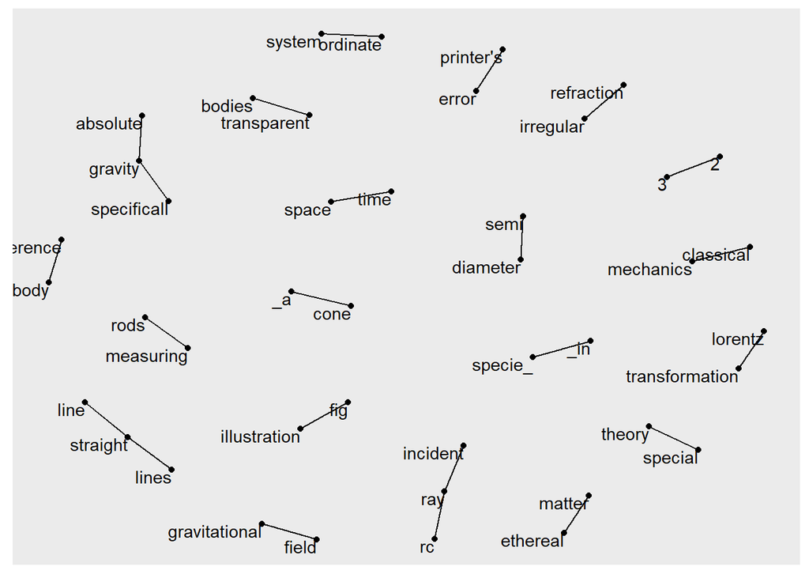

```r
library(ggraph)
set.seed(2000)

ggraph(bigram_graph, layout = "fr") +
  geom_edge_link() +
  geom_node_point() +
  geom_node_text(aes(label = name), vjust = 1, hjust = 1)
```

We add the edge_alpha aesthetic to the link layer to make links transparent based on how common or rare the bigram is We add directionality with an arrow, constructed using grid::arrow(), including an end_cap option that tells the arrow to end before touching the node We tinker with the options to the node layer to make the nodes more attractive (larger, blue points) We add a theme that’s useful for plotting networks, theme_void()

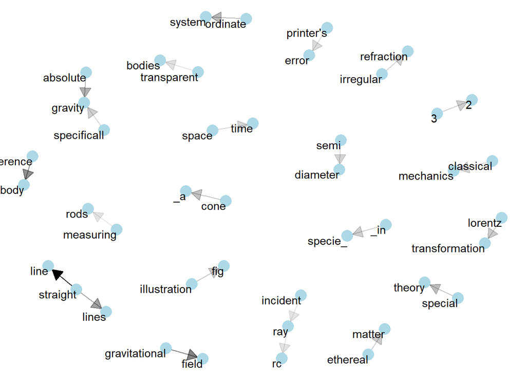

```r
set.seed(2000)

a <- grid::arrow(type = "closed", length = unit(.15, "inches"))

ggraph(bigram_graph, layout = "fr") +
  geom_edge_link(aes(edge_alpha = n), show.legend = FALSE,
                 arrow = a, end_cap = circle(.07, 'inches')) +
  geom_node_point(color = "lightblue", size = 5) +
  geom_node_text(aes(label = name), vjust = 1, hjust = 1) +
  theme_void()
```

#************************************************************************** # Citations #**************************************************************************

Silge J. and Robinson D. (2017) Text Mining with R: A Tidy Approach (1st. ed.). O’Reilly Media, Inc.

This project is heavily adapted from the [website](https://www.tidytextmining.com/) for Text Mining with R! Visit the [GitHub repository](https://github.com/dgrtwo/tidy-text-mining) for this site, find the [book at O’Reilly](http://shop.oreilly.com/product/0636920067153.do?cmp=af-strata-books-video-product_cj_0636920067153_4428796), or buy it on https://www.amazon.com/gp/product/1491981652/ref=as_li_tl?ie=UTF8&tag=juliasilge-20&camp=1789&creative=9325&linkCode=as2&creativeASIN=1491981652&linkId=0e92d44b0aa39ab34608ffa582dbd490.

```r
citation("dplyr")
```

```
##
##
##   Hadley Wickham, Romain François, Lionel Henry and Kirill Müller
##   (2019). dplyr: A Grammar of Data Manipulation. R package version
##   0.8.3. https://CRAN.R-project.org/package=dplyr
##
## A BibTeX entry for LaTeX users is
##
##   @Manual{,
##     title = {dplyr: A Grammar of Data Manipulation},
##     author = {Hadley Wickham and Romain François and Lionel Henry and Kirill Müller},
##     year = {2019},
##     note = {R package version 0.8.3},
##     url = {https://CRAN.R-project.org/package=dplyr},
##   }
```

```r
citation("tidytext")
```

```
##
## Silge J, Robinson D (2016). "tidytext: Text Mining and Analysis Using
## Tidy Data Principles in R." _JOSS_, *1*(3). doi: 10.21105/joss.00037
## (URL: https://doi.org/10.21105/joss.00037), <URL:
## http://dx.doi.org/10.21105/joss.00037>.
##
## A BibTeX entry for LaTeX users is
##
##   @Article{,
##     title = {tidytext: Text Mining and Analysis Using Tidy Data Principles in R},
##     author = {Julia Silge and David Robinson},
##     doi = {10.21105/joss.00037},
##     url = {http://dx.doi.org/10.21105/joss.00037},
##     year = {2016},
##     publisher = {The Open Journal},
##     volume = {1},
##     number = {3},
##     journal = {JOSS},
##   }
```

```r
citation("ggplot2")
```

```
##
##
##   H. Wickham. ggplot2: Elegant Graphics for Data Analysis.
##   Springer-Verlag New York, 2016.
##
## A BibTeX entry for LaTeX users is
##
##   @Book{,
##     author = {Hadley Wickham},
##     title = {ggplot2: Elegant Graphics for Data Analysis},
##     publisher = {Springer-Verlag New York},
##     year = {2016},
##     isbn = {978-3-319-24277-4},
##     url = {https://ggplot2.tidyverse.org},
##   }
```

```r
citation("gutenbergr")
```

```
##
##
##   David Robinson (2019). gutenbergr: Download and Process Public Domain
##   Works from Project Gutenberg. R package version 0.1.5.
##   https://CRAN.R-project.org/package=gutenbergr
##
## A BibTeX entry for LaTeX users is
##
##   @Manual{,
##     title = {gutenbergr: Download and Process Public Domain Works from Project Gutenberg},
##     author = {David Robinson},
##     year = {2019},
##     note = {R package version 0.1.5},
##     url = {https://CRAN.R-project.org/package=gutenbergr},
##   }
```

```r
citation("forcats")
```

```
##
##
##   Hadley Wickham (2019). forcats: Tools for Working with Categorical
##   Variables (Factors). R package version 0.4.0.
##   https://CRAN.R-project.org/package=forcats
##
## A BibTeX entry for LaTeX users is
##
##   @Manual{,
##     title = {forcats: Tools for Working with Categorical Variables (Factors)},
##     author = {Hadley Wickham},
##     year = {2019},
##     note = {R package version 0.4.0},
##     url = {https://CRAN.R-project.org/package=forcats},
##   }
```

```r
citation("stringr")
```

```
##
##
##   Hadley Wickham (2019). stringr: Simple, Consistent Wrappers for
##   Common String Operations. R package version 1.4.0.
##   https://CRAN.R-project.org/package=stringr
##
## A BibTeX entry for LaTeX users is
##
##   @Manual{,
##     title = {stringr: Simple, Consistent Wrappers for Common String Operations},
##     author = {Hadley Wickham},
##     year = {2019},
##     note = {R package version 1.4.0},
##     url = {https://CRAN.R-project.org/package=stringr},
##   }
```

```r
citation("wordcloud")
```

```
##
##
##   Ian Fellows (2018). wordcloud: Word Clouds. R package version 2.6.
##   https://CRAN.R-project.org/package=wordcloud
##
## A BibTeX entry for LaTeX users is
##
##   @Manual{,
##     title = {wordcloud: Word Clouds},
##     author = {Ian Fellows},
##     year = {2018},
##     note = {R package version 2.6},
##     url = {https://CRAN.R-project.org/package=wordcloud},
##   }
##
## ATTENTION: This citation information has been auto-generated from the
## package DESCRIPTION file and may need manual editing, see
## 'help("citation")'.
```

```r
citation("tidyr")
```

```
##
##
##   Hadley Wickham and Lionel Henry (2020). tidyr: Tidy Messy Data. R
##   package version 1.0.2. https://CRAN.R-project.org/package=tidyr
##
## A BibTeX entry for LaTeX users is
##
##   @Manual{,
##     title = {tidyr: Tidy Messy Data},
##     author = {Hadley Wickham and Lionel Henry},
##     year = {2020},
##     note = {R package version 1.0.2},
##     url = {https://CRAN.R-project.org/package=tidyr},
##   }
```

```r
citation("igraph")
```

```
##
##
##   Csardi G, Nepusz T: The igraph software package for complex network
##   research, InterJournal, Complex Systems 1695. 2006. http://igraph.org
##
## A BibTeX entry for LaTeX users is
##
##   @Article{,
##     title = {The igraph software package for complex network research},
##     author = {Gabor Csardi and Tamas Nepusz},
##     journal = {InterJournal},
##     volume = {Complex Systems},
##     pages = {1695},
##     year = {2006},
##     url = {http://igraph.org},
##   }
```

```r
citation("ggraph")
```

```
##
##
##   Thomas Lin Pedersen (2020). ggraph: An Implementation of Grammar of
##   Graphics for Graphs and Networks. R package version 2.0.1.
##   https://CRAN.R-project.org/package=ggraph
##
## A BibTeX entry for LaTeX users is
##
##   @Manual{,
##     title = {ggraph: An Implementation of Grammar of Graphics for Graphs and Networks},
##     author = {Thomas Lin Pedersen},
##     year = {2020},
##     note = {R package version 2.0.1},
##     url = {https://CRAN.R-project.org/package=ggraph},
##   }
```